# Risk Factor Analysis

## Outcome Variable

**Outcome Variable:** sstunted

## Predictor Variables

**Intervention Variable:** impsan

**Adjustment Set:**

- arm
- sex
- W_mage
- meducyrs
- feducyrs
- hhwealth_quart
- hfoodsec
- W_mhtcm
- W_mwtkg
- W_mbmi
- W_nrooms
- W_nchldlt5
- W_parity
- impfloor
- safeh20
- delta_W_mage
- delta_meducyrs
- delta_feducyrs
- delta_hhwealth_quart
- delta_hfoodsec
- delta_W_mhtcm
- delta_W_mwtkg
- delta_W_mbmi
- delta_W_nrooms
- delta_W_nchldlt5
- delta_W_parity
- delta_impfloor
- delta_safeh20

## Stratifying Variables

The analysis was stratified on these variable(s):

- agecat
- studyid
- country

## Data Summary

| agecat | studyid | country | impsan | sstunted | n_cell | n |
| --- | --- | --- | --- | --- | --- | --- |
| Birth | ki0047075b-MAL-ED | BANGLADESH | 1 | 0 | 174 | 213 |
| Birth | ki0047075b-MAL-ED | BANGLADESH | 1 | 1 | 5 | 213 |
| Birth | ki0047075b-MAL-ED | BANGLADESH | 0 | 0 | 33 | 213 |
| Birth | ki0047075b-MAL-ED | BANGLADESH | 0 | 1 | 1 | 213 |
| Birth | ki0047075b-MAL-ED | BRAZIL | 1 | 0 | 56 | 60 |
| Birth | ki0047075b-MAL-ED | BRAZIL | 1 | 1 | 3 | 60 |
| Birth | ki0047075b-MAL-ED | BRAZIL | 0 | 0 | 1 | 60 |
| Birth | ki0047075b-MAL-ED | BRAZIL | 0 | 1 | 0 | 60 |
| Birth | ki0047075b-MAL-ED | INDIA | 1 | 0 | 14 | 40 |
| Birth | ki0047075b-MAL-ED | INDIA | 1 | 1 | 1 | 40 |
| Birth | ki0047075b-MAL-ED | INDIA | 0 | 0 | 25 | 40 |
| Birth | ki0047075b-MAL-ED | INDIA | 0 | 1 | 0 | 40 |
| Birth | ki0047075b-MAL-ED | NEPAL | 1 | 0 | 24 | 26 |
| Birth | ki0047075b-MAL-ED | NEPAL | 1 | 1 | 1 | 26 |
| Birth | ki0047075b-MAL-ED | NEPAL | 0 | 0 | 1 | 26 |
| Birth | ki0047075b-MAL-ED | NEPAL | 0 | 1 | 0 | 26 |
| Birth | ki0047075b-MAL-ED | PERU | 1 | 0 | 50 | 208 |
| Birth | ki0047075b-MAL-ED | PERU | 1 | 1 | 2 | 208 |
| Birth | ki0047075b-MAL-ED | PERU | 0 | 0 | 154 | 208 |
| Birth | ki0047075b-MAL-ED | PERU | 0 | 1 | 2 | 208 |
| Birth | ki0047075b-MAL-ED | SOUTH AFRICA | 1 | 0 | 0 | 95 |
| Birth | ki0047075b-MAL-ED | SOUTH AFRICA | 1 | 1 | 0 | 95 |
| Birth | ki0047075b-MAL-ED | SOUTH AFRICA | 0 | 0 | 94 | 95 |
| Birth | ki0047075b-MAL-ED | SOUTH AFRICA | 0 | 1 | 1 | 95 |
| Birth | ki0047075b-MAL-ED | TANZANIA, UNITED REPUBLIC OF | 1 | 0 | 0 | 118 |
| Birth | ki0047075b-MAL-ED | TANZANIA, UNITED REPUBLIC OF | 1 | 1 | 0 | 118 |
| Birth | ki0047075b-MAL-ED | TANZANIA, UNITED REPUBLIC OF | 0 | 0 | 110 | 118 |
| Birth | ki0047075b-MAL-ED | TANZANIA, UNITED REPUBLIC OF | 0 | 1 | 8 | 118 |
| Birth | ki1017093-NIH-Birth | BANGLADESH | 1 | 0 | 226 | 608 |
| Birth | ki1017093-NIH-Birth | BANGLADESH | 1 | 1 | 5 | 608 |

[output cut: 170 more lines]

The following strata were considered:

- agecat: 24 months, studyid: ki0047075b-MAL-ED, country: BANGLADESH
- agecat: 24 months, studyid: ki0047075b-MAL-ED, country: BRAZIL
- agecat: 24 months, studyid: ki0047075b-MAL-ED, country: INDIA
- agecat: 24 months, studyid: ki0047075b-MAL-ED, country: NEPAL
- agecat: 24 months, studyid: ki0047075b-MAL-ED, country: PERU
- agecat: 24 months, studyid: ki0047075b-MAL-ED, country: SOUTH AFRICA
- agecat: 24 months, studyid: ki0047075b-MAL-ED, country: TANZANIA, UNITED REPUBLIC OF
- agecat: 24 months, studyid: ki1017093-NIH-Birth, country: BANGLADESH
- agecat: 24 months, studyid: ki1017093b-PROVIDE, country: BANGLADESH
- agecat: 24 months, studyid: ki1017093c-NIH-Crypto, country: BANGLADESH
- agecat: 24 months, studyid: ki1114097-CONTENT, country: PERU
- agecat: 24 months, studyid: ki1135781-COHORTS, country: GUATEMALA
- agecat: 24 months, studyid: ki1135781-COHORTS, country: INDIA
- agecat: 24 months, studyid: ki1135781-COHORTS, country: PHILIPPINES
- agecat: 24 months, studyid: ki1148112-LCNI-5, country: MALAWI
- agecat: 24 months, studyid: kiGH5241-JiVitA-3, country: BANGLADESH
- agecat: 24 months, studyid: kiGH5241-JiVitA-4, country: BANGLADESH
- agecat: 6 months, studyid: ki0047075b-MAL-ED, country: BANGLADESH
- agecat: 6 months, studyid: ki0047075b-MAL-ED, country: BRAZIL
- agecat: 6 months, studyid: ki0047075b-MAL-ED, country: INDIA
- agecat: 6 months, studyid: ki0047075b-MAL-ED, country: NEPAL
- agecat: 6 months, studyid: ki0047075b-MAL-ED, country: PERU
- agecat: 6 months, studyid: ki0047075b-MAL-ED, country: SOUTH AFRICA
- agecat: 6 months, studyid: ki0047075b-MAL-ED, country: TANZANIA, UNITED REPUBLIC OF
- agecat: 6 months, studyid: ki1017093-NIH-Birth, country: BANGLADESH
- agecat: 6 months, studyid: ki1017093b-PROVIDE, country: BANGLADESH
- agecat: 6 months, studyid: ki1017093c-NIH-Crypto, country: BANGLADESH
- agecat: 6 months, studyid: ki1114097-CONTENT, country: PERU
- agecat: 6 months, studyid: ki1135781-COHORTS, country: GUATEMALA
- agecat: 6 months, studyid: ki1135781-COHORTS, country: INDIA
- agecat: 6 months, studyid: ki1135781-COHORTS, country: PHILIPPINES
- agecat: 6 months, studyid: ki1148112-LCNI-5, country: MALAWI
- agecat: 6 months, studyid: kiGH5241-JiVitA-3, country: BANGLADESH
- agecat: 6 months, studyid: kiGH5241-JiVitA-4, country: BANGLADESH
- agecat: Birth, studyid: ki0047075b-MAL-ED, country: BANGLADESH
- agecat: Birth, studyid: ki0047075b-MAL-ED, country: BRAZIL
- agecat: Birth, studyid: ki0047075b-MAL-ED, country: INDIA
- agecat: Birth, studyid: ki0047075b-MAL-ED, country: NEPAL
- agecat: Birth, studyid: ki0047075b-MAL-ED, country: PERU
- agecat: Birth, studyid: ki0047075b-MAL-ED, country: SOUTH AFRICA
- agecat: Birth, studyid: ki0047075b-MAL-ED, country: TANZANIA, UNITED REPUBLIC OF
- agecat: Birth, studyid: ki1017093-NIH-Birth, country: BANGLADESH
- agecat: Birth, studyid: ki1017093b-PROVIDE, country: BANGLADESH
- agecat: Birth, studyid: ki1017093c-NIH-Crypto, country: BANGLADESH
- agecat: Birth, studyid: ki1114097-CONTENT, country: PERU
- agecat: Birth, studyid: ki1135781-COHORTS, country: GUATEMALA
- agecat: Birth, studyid: ki1135781-COHORTS, country: INDIA
- agecat: Birth, studyid: ki1135781-COHORTS, country: PHILIPPINES
- agecat: Birth, studyid: kiGH5241-JiVitA-3, country: BANGLADESH
- agecat: Birth, studyid: kiGH5241-JiVitA-4, country: BANGLADESH

### Dropped Strata

Some strata were dropped due to rare outcomes:

- agecat: Birth, studyid: ki0047075b-MAL-ED, country: BANGLADESH
- agecat: Birth, studyid: ki0047075b-MAL-ED, country: BRAZIL
- agecat: Birth, studyid: ki0047075b-MAL-ED, country: INDIA
- agecat: Birth, studyid: ki0047075b-MAL-ED, country: NEPAL
- agecat: Birth, studyid: ki0047075b-MAL-ED, country: PERU
- agecat: Birth, studyid: ki0047075b-MAL-ED, country: SOUTH AFRICA
- agecat: Birth, studyid: ki0047075b-MAL-ED, country: TANZANIA, UNITED REPUBLIC OF
- agecat: Birth, studyid: ki1017093b-PROVIDE, country: BANGLADESH
- agecat: Birth, studyid: ki1017093c-NIH-Crypto, country: BANGLADESH
- agecat: Birth, studyid: ki1114097-CONTENT, country: PERU
- agecat: Birth, studyid: ki1135781-COHORTS, country: GUATEMALA
- agecat: Birth, studyid: ki1135781-COHORTS, country: PHILIPPINES
- agecat: 6 months, studyid: ki0047075b-MAL-ED, country: BANGLADESH
- agecat: 6 months, studyid: ki0047075b-MAL-ED, country: BRAZIL
- agecat: 6 months, studyid: ki0047075b-MAL-ED, country: INDIA
- agecat: 6 months, studyid: ki0047075b-MAL-ED, country: NEPAL
- agecat: 6 months, studyid: ki0047075b-MAL-ED, country: PERU
- agecat: 6 months, studyid: ki0047075b-MAL-ED, country: SOUTH AFRICA
- agecat: 6 months, studyid: ki0047075b-MAL-ED, country: TANZANIA, UNITED REPUBLIC OF
- agecat: 6 months, studyid: ki1017093b-PROVIDE, country: BANGLADESH
- agecat: 6 months, studyid: ki1114097-CONTENT, country: PERU
- agecat: 6 months, studyid: ki1135781-COHORTS, country: GUATEMALA
- agecat: 6 months, studyid: ki1135781-COHORTS, country: PHILIPPINES
- agecat: 6 months, studyid: ki1148112-LCNI-5, country: MALAWI
- agecat: 24 months, studyid: ki0047075b-MAL-ED, country: BANGLADESH
- agecat: 24 months, studyid: ki0047075b-MAL-ED, country: BRAZIL
- agecat: 24 months, studyid: ki0047075b-MAL-ED, country: NEPAL
- agecat: 24 months, studyid: ki0047075b-MAL-ED, country: PERU
- agecat: 24 months, studyid: ki0047075b-MAL-ED, country: SOUTH AFRICA
- agecat: 24 months, studyid: ki0047075b-MAL-ED, country: TANZANIA, UNITED REPUBLIC OF
- agecat: 24 months, studyid: ki1017093b-PROVIDE, country: BANGLADESH
- agecat: 24 months, studyid: ki1114097-CONTENT, country: PERU
- agecat: 24 months, studyid: ki1148112-LCNI-5, country: MALAWI

## Methods Detail

We’re interested in the causal parameters $E[Y_a]$ for all values of $a \in \mathcal{A}$. These parameters represent the mean outcome if, possibly contrary to fact, we intervened to set all units to have $A=a$. Under the randomization and positivity assumptions, these are identified by the statistical parameters $\psi_a=E_W[E_{Y|A,W}(Y|A=a,W)]$. In addition, we’re interested in the mean of $Y$, $E[Y]$ under no intervention (the observed mean). We will estimate these parameters by using SuperLearner to fit the relevant likelihood factors – $E_{Y|A,W}(Y|A=a,W)$ and $p(A=a|W)$, and then updating our likelihood fit using a joint TMLE.

For unadjusted analyses ($W=\{\}$), initial likelihoods were estimated using Lrnr_glm to estimate the simple $E(Y|A)$ and Lrnr_mean to estimate $p(A)$. For adjusted analyses, a small library containing Lrnr_glmnet, Lrnr_xgboost, and Lrnr_mean was used.

Having estimated these parameters, we will then use the delta method to estimate relative risks and attributable risks relative to a prespecified baseline level of $A$.

# Results Detail

## Results Plots

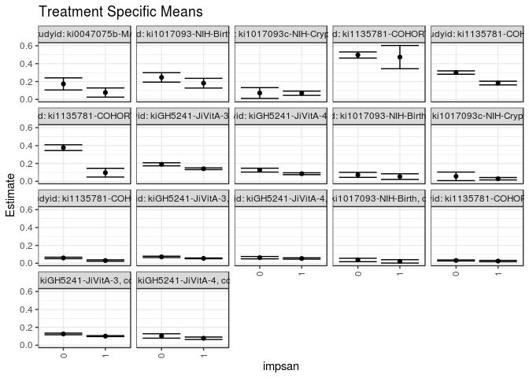

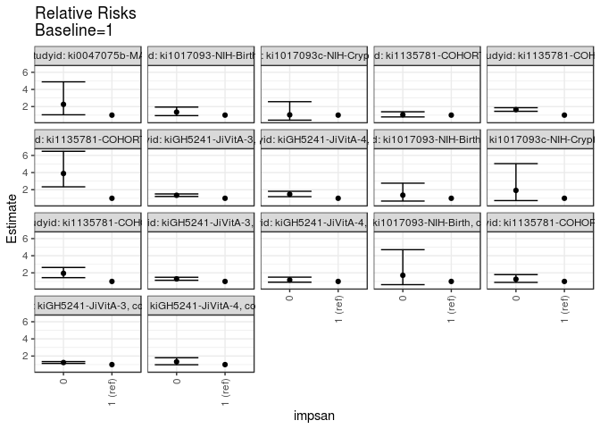

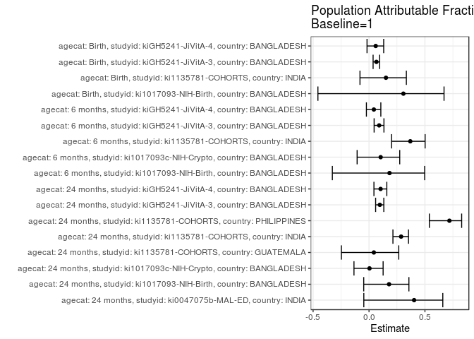

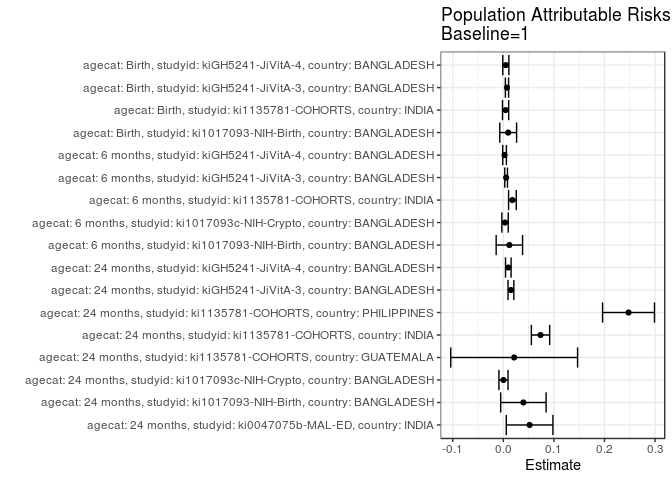

## Results Table

### Parameter: TSM

| agecat | studyid | country | intervention_level | baseline_level | estimate | ci_lower | ci_upper |
| --- | --- | --- | --- | --- | --- | --- | --- |
| Birth | ki1017093-NIH-Birth | BANGLADESH | 1 | NA | 0.0216450 | 0.0028637 | 0.0404264 |
| Birth | ki1017093-NIH-Birth | BANGLADESH | 0 | NA | 0.0371353 | 0.0180319 | 0.0562387 |
| Birth | ki1135781-COHORTS | INDIA | 1 | NA | 0.0250516 | 0.0177580 | 0.0323452 |
| Birth | ki1135781-COHORTS | INDIA | 0 | NA | 0.0316469 | 0.0254105 | 0.0378833 |
| Birth | kiGH5241-JiVitA-3 | BANGLADESH | 1 | NA | 0.1019060 | 0.0963800 | 0.1074319 |
| Birth | kiGH5241-JiVitA-3 | BANGLADESH | 0 | NA | 0.1262655 | 0.1171749 | 0.1353560 |
| Birth | kiGH5241-JiVitA-4 | BANGLADESH | 1 | NA | 0.0776930 | 0.0639683 | 0.0914176 |
| Birth | kiGH5241-JiVitA-4 | BANGLADESH | 0 | NA | 0.1033897 | 0.0786148 | 0.1281647 |
| 6 months | ki1017093-NIH-Birth | BANGLADESH | 1 | NA | 0.0532327 | 0.0220464 | 0.0844189 |
| 6 months | ki1017093-NIH-Birth | BANGLADESH | 0 | NA | 0.0727234 | 0.0445281 | 0.1009187 |
| 6 months | ki1017093c-NIH-Crypto | BANGLADESH | 1 | NA | 0.0292683 | 0.0159371 | 0.0425994 |
| 6 months | ki1017093c-NIH-Crypto | BANGLADESH | 0 | NA | 0.0561798 | 0.0083061 | 0.1040534 |
| 6 months | ki1135781-COHORTS | INDIA | 1 | NA | 0.0307144 | 0.0225565 | 0.0388722 |
| 6 months | ki1135781-COHORTS | INDIA | 0 | NA | 0.0598166 | 0.0513762 | 0.0682570 |
| 6 months | kiGH5241-JiVitA-3 | BANGLADESH | 1 | NA | 0.0551602 | 0.0507610 | 0.0595595 |
| 6 months | kiGH5241-JiVitA-3 | BANGLADESH | 0 | NA | 0.0716459 | 0.0636133 | 0.0796785 |
| 6 months | kiGH5241-JiVitA-4 | BANGLADESH | 1 | NA | 0.0537330 | 0.0461158 | 0.0613501 |
| 6 months | kiGH5241-JiVitA-4 | BANGLADESH | 0 | NA | 0.0629410 | 0.0498353 | 0.0760467 |
| 24 months | ki0047075b-MAL-ED | INDIA | 1 | NA | 0.0769231 | 0.0255961 | 0.1282501 |
| 24 months | ki0047075b-MAL-ED | INDIA | 0 | NA | 0.1735537 | 0.1059225 | 0.2411849 |
| 24 months | ki1017093-NIH-Birth | BANGLADESH | 1 | NA | 0.1817844 | 0.1271812 | 0.2363877 |
| 24 months | ki1017093-NIH-Birth | BANGLADESH | 0 | NA | 0.2461213 | 0.1933213 | 0.2989214 |
| 24 months | ki1017093c-NIH-Crypto | BANGLADESH | 1 | NA | 0.0692841 | 0.0453420 | 0.0932261 |
| 24 months | ki1017093c-NIH-Crypto | BANGLADESH | 0 | NA | 0.0714286 | 0.0110372 | 0.1318199 |
| 24 months | ki1135781-COHORTS | GUATEMALA | 1 | NA | 0.4735574 | 0.3434773 | 0.6036376 |
| 24 months | ki1135781-COHORTS | GUATEMALA | 0 | NA | 0.4966653 | 0.4622364 | 0.5310943 |
| 24 months | ki1135781-COHORTS | INDIA | 1 | NA | 0.1829239 | 0.1621938 | 0.2036540 |
| 24 months | ki1135781-COHORTS | INDIA | 0 | NA | 0.3004702 | 0.2817049 | 0.3192355 |
| 24 months | ki1135781-COHORTS | PHILIPPINES | 1 | NA | 0.0968817 | 0.0479410 | 0.1458225 |
| 24 months | ki1135781-COHORTS | PHILIPPINES | 0 | NA | 0.3770842 | 0.3448388 | 0.4093296 |
| 24 months | kiGH5241-JiVitA-3 | BANGLADESH | 1 | NA | 0.1409527 | 0.1310978 | 0.1508075 |
| 24 months | kiGH5241-JiVitA-3 | BANGLADESH | 0 | NA | 0.1905868 | 0.1734271 | 0.2077464 |
| 24 months | kiGH5241-JiVitA-4 | BANGLADESH | 1 | NA | 0.0853720 | 0.0749240 | 0.0958200 |
| 24 months | kiGH5241-JiVitA-4 | BANGLADESH | 0 | NA | 0.1255201 | 0.1039269 | 0.1471132 |

### Parameter: E(Y)

| agecat | studyid | country | intervention_level | baseline_level | estimate | ci_lower | ci_upper |
| --- | --- | --- | --- | --- | --- | --- | --- |
| Birth | ki1017093-NIH-Birth | BANGLADESH | NA | NA | 0.0312500 | 0.0174085 | 0.0450915 |
| Birth | ki1135781-COHORTS | INDIA | NA | NA | 0.0295226 | 0.0247216 | 0.0343236 |
| Birth | kiGH5241-JiVitA-3 | BANGLADESH | NA | NA | 0.1091347 | 0.1045758 | 0.1136935 |
| Birth | kiGH5241-JiVitA-4 | BANGLADESH | NA | NA | 0.0826241 | 0.0709364 | 0.0943118 |
| 6 months | ki1017093-NIH-Birth | BANGLADESH | NA | NA | 0.0651769 | 0.0442802 | 0.0860736 |
| 6 months | ki1017093c-NIH-Crypto | BANGLADESH | NA | NA | 0.0326705 | 0.0195292 | 0.0458117 |
| 6 months | ki1135781-COHORTS | INDIA | NA | NA | 0.0486824 | 0.0426994 | 0.0546654 |
| 6 months | kiGH5241-JiVitA-3 | BANGLADESH | NA | NA | 0.0606548 | 0.0567999 | 0.0645096 |
| 6 months | kiGH5241-JiVitA-4 | BANGLADESH | NA | NA | 0.0561658 | 0.0493946 | 0.0629370 |
| 24 months | ki0047075b-MAL-ED | INDIA | NA | NA | 0.1288889 | 0.0850087 | 0.1727691 |
| 24 months | ki1017093-NIH-Birth | BANGLADESH | NA | NA | 0.2214452 | 0.1821080 | 0.2607825 |
| 24 months | ki1017093c-NIH-Crypto | BANGLADESH | NA | NA | 0.0695825 | 0.0473246 | 0.0918405 |
| 24 months | ki1135781-COHORTS | GUATEMALA | NA | NA | 0.4949608 | 0.4621502 | 0.5277714 |
| 24 months | ki1135781-COHORTS | INDIA | NA | NA | 0.2564649 | 0.2424885 | 0.2704414 |
| 24 months | ki1135781-COHORTS | PHILIPPINES | NA | NA | 0.3444444 | 0.3148293 | 0.3740596 |
| 24 months | kiGH5241-JiVitA-3 | BANGLADESH | NA | NA | 0.1559963 | 0.1472522 | 0.1647404 |
| 24 months | kiGH5241-JiVitA-4 | BANGLADESH | NA | NA | 0.0952180 | 0.0856733 | 0.1047628 |

### Parameter: RR

| agecat | studyid | country | intervention_level | baseline_level | estimate | ci_lower | ci_upper |
| --- | --- | --- | --- | --- | --- | --- | --- |
| Birth | ki1017093-NIH-Birth | BANGLADESH | 1 | 1 | 1.000000 | 1.0000000 | 1.000000 |
| Birth | ki1017093-NIH-Birth | BANGLADESH | 0 | 1 | 1.715650 | 0.6256664 | 4.704511 |
| Birth | ki1135781-COHORTS | INDIA | 1 | 1 | 1.000000 | 1.0000000 | 1.000000 |
| Birth | ki1135781-COHORTS | INDIA | 0 | 1 | 1.263269 | 0.8887225 | 1.795665 |
| Birth | kiGH5241-JiVitA-3 | BANGLADESH | 1 | 1 | 1.000000 | 1.0000000 | 1.000000 |
| Birth | kiGH5241-JiVitA-3 | BANGLADESH | 0 | 1 | 1.239039 | 1.1361618 | 1.351232 |
| Birth | kiGH5241-JiVitA-4 | BANGLADESH | 1 | 1 | 1.000000 | 1.0000000 | 1.000000 |
| Birth | kiGH5241-JiVitA-4 | BANGLADESH | 0 | 1 | 1.330748 | 0.9846483 | 1.798500 |
| 6 months | ki1017093-NIH-Birth | BANGLADESH | 1 | 1 | 1.000000 | 1.0000000 | 1.000000 |
| 6 months | ki1017093-NIH-Birth | BANGLADESH | 0 | 1 | 1.366143 | 0.6754098 | 2.763281 |
| 6 months | ki1017093c-NIH-Crypto | BANGLADESH | 1 | 1 | 1.000000 | 1.0000000 | 1.000000 |
| 6 months | ki1017093c-NIH-Crypto | BANGLADESH | 0 | 1 | 1.919476 | 0.7303803 | 5.044477 |
| 6 months | ki1135781-COHORTS | INDIA | 1 | 1 | 1.000000 | 1.0000000 | 1.000000 |
| 6 months | ki1135781-COHORTS | INDIA | 0 | 1 | 1.947510 | 1.4419371 | 2.630348 |
| 6 months | kiGH5241-JiVitA-3 | BANGLADESH | 1 | 1 | 1.000000 | 1.0000000 | 1.000000 |
| 6 months | kiGH5241-JiVitA-3 | BANGLADESH | 0 | 1 | 1.298869 | 1.1350475 | 1.486335 |
| 6 months | kiGH5241-JiVitA-4 | BANGLADESH | 1 | 1 | 1.000000 | 1.0000000 | 1.000000 |
| 6 months | kiGH5241-JiVitA-4 | BANGLADESH | 0 | 1 | 1.171366 | 0.9137927 | 1.501543 |
| 24 months | ki0047075b-MAL-ED | INDIA | 1 | 1 | 1.000000 | 1.0000000 | 1.000000 |
| 24 months | ki0047075b-MAL-ED | INDIA | 0 | 1 | 2.256198 | 1.0418240 | 4.886076 |
| 24 months | ki1017093-NIH-Birth | BANGLADESH | 1 | 1 | 1.000000 | 1.0000000 | 1.000000 |
| 24 months | ki1017093-NIH-Birth | BANGLADESH | 0 | 1 | 1.353919 | 0.9445471 | 1.940714 |
| 24 months | ki1017093c-NIH-Crypto | BANGLADESH | 1 | 1 | 1.000000 | 1.0000000 | 1.000000 |
| 24 months | ki1017093c-NIH-Crypto | BANGLADESH | 0 | 1 | 1.030952 | 0.4135862 | 2.569870 |
| 24 months | ki1135781-COHORTS | GUATEMALA | 1 | 1 | 1.000000 | 1.0000000 | 1.000000 |
| 24 months | ki1135781-COHORTS | GUATEMALA | 0 | 1 | 1.048796 | 0.7900563 | 1.392273 |
| 24 months | ki1135781-COHORTS | INDIA | 1 | 1 | 1.000000 | 1.0000000 | 1.000000 |
| 24 months | ki1135781-COHORTS | INDIA | 0 | 1 | 1.642597 | 1.4459414 | 1.865998 |
| 24 months | ki1135781-COHORTS | PHILIPPINES | 1 | 1 | 1.000000 | 1.0000000 | 1.000000 |
| 24 months | ki1135781-COHORTS | PHILIPPINES | 0 | 1 | 3.892211 | 2.3355334 | 6.486445 |
| 24 months | kiGH5241-JiVitA-3 | BANGLADESH | 1 | 1 | 1.000000 | 1.0000000 | 1.000000 |
| 24 months | kiGH5241-JiVitA-3 | BANGLADESH | 0 | 1 | 1.352133 | 1.2137194 | 1.506331 |
| 24 months | kiGH5241-JiVitA-4 | BANGLADESH | 1 | 1 | 1.000000 | 1.0000000 | 1.000000 |
| 24 months | kiGH5241-JiVitA-4 | BANGLADESH | 0 | 1 | 1.470272 | 1.1913366 | 1.814516 |

### Parameter: PAR

| agecat | studyid | country | intervention_level | baseline_level | estimate | ci_lower | ci_upper |
| --- | --- | --- | --- | --- | --- | --- | --- |
| Birth | ki1017093-NIH-Birth | BANGLADESH | 1 | NA | 0.0096050 | -0.0070171 | 0.0262270 |
| Birth | ki1135781-COHORTS | INDIA | 1 | NA | 0.0044711 | -0.0016357 | 0.0105778 |
| Birth | kiGH5241-JiVitA-3 | BANGLADESH | 1 | NA | 0.0072287 | 0.0040396 | 0.0104179 |
| Birth | kiGH5241-JiVitA-4 | BANGLADESH | 1 | NA | 0.0049312 | -0.0011059 | 0.0109682 |
| 6 months | ki1017093-NIH-Birth | BANGLADESH | 1 | NA | 0.0119443 | -0.0141590 | 0.0380475 |
| 6 months | ki1017093c-NIH-Crypto | BANGLADESH | 1 | NA | 0.0034022 | -0.0029150 | 0.0097193 |
| 6 months | ki1135781-COHORTS | INDIA | 1 | NA | 0.0179680 | 0.0104003 | 0.0255357 |
| 6 months | kiGH5241-JiVitA-3 | BANGLADESH | 1 | NA | 0.0054945 | 0.0028069 | 0.0081821 |
| 6 months | kiGH5241-JiVitA-4 | BANGLADESH | 1 | NA | 0.0024328 | -0.0011796 | 0.0060453 |
| 24 months | ki0047075b-MAL-ED | INDIA | 1 | NA | 0.0519658 | 0.0058733 | 0.0980583 |
| 24 months | ki1017093-NIH-Birth | BANGLADESH | 1 | NA | 0.0396608 | -0.0052349 | 0.0845565 |
| 24 months | ki1017093c-NIH-Crypto | BANGLADESH | 1 | NA | 0.0002984 | -0.0087425 | 0.0093394 |
| 24 months | ki1135781-COHORTS | GUATEMALA | 1 | NA | 0.0214034 | -0.1040111 | 0.1468178 |
| 24 months | ki1135781-COHORTS | INDIA | 1 | NA | 0.0735410 | 0.0554468 | 0.0916352 |
| 24 months | ki1135781-COHORTS | PHILIPPINES | 1 | NA | 0.2475627 | 0.1962132 | 0.2989123 |
| 24 months | kiGH5241-JiVitA-3 | BANGLADESH | 1 | NA | 0.0150436 | 0.0092947 | 0.0207925 |
| 24 months | kiGH5241-JiVitA-4 | BANGLADESH | 1 | NA | 0.0098460 | 0.0043489 | 0.0153431 |

### Parameter: PAF

| agecat | studyid | country | intervention_level | baseline_level | estimate | ci_lower | ci_upper |
| --- | --- | --- | --- | --- | --- | --- | --- |
| Birth | ki1017093-NIH-Birth | BANGLADESH | 1 | NA | 0.3073593 | -0.4568509 | 0.6706930 |
| Birth | ki1135781-COHORTS | INDIA | 1 | NA | 0.1514450 | -0.0808328 | 0.3338049 |
| Birth | kiGH5241-JiVitA-3 | BANGLADESH | 1 | NA | 0.0662367 | 0.0364585 | 0.0950946 |
| Birth | kiGH5241-JiVitA-4 | BANGLADESH | 1 | NA | 0.0596818 | -0.0178030 | 0.1312677 |
| 6 months | ki1017093-NIH-Birth | BANGLADESH | 1 | NA | 0.1832590 | -0.3278922 | 0.4976506 |
| 6 months | ki1017093c-NIH-Crypto | BANGLADESH | 1 | NA | 0.1041357 | -0.1063416 | 0.2745705 |
| 6 months | ki1135781-COHORTS | INDIA | 1 | NA | 0.3690860 | 0.2014801 | 0.5015122 |
| 6 months | kiGH5241-JiVitA-3 | BANGLADESH | 1 | NA | 0.0905870 | 0.0455851 | 0.1334670 |
| 6 months | kiGH5241-JiVitA-4 | BANGLADESH | 1 | NA | 0.0433151 | -0.0233407 | 0.1056292 |
| 24 months | ki0047075b-MAL-ED | INDIA | 1 | NA | 0.4031830 | -0.0465924 | 0.6596664 |
| 24 months | ki1017093-NIH-Birth | BANGLADESH | 1 | NA | 0.1790998 | -0.0473424 | 0.3565837 |
| 24 months | ki1017093c-NIH-Crypto | BANGLADESH | 1 | NA | 0.0042890 | -0.1344942 | 0.1260948 |
| 24 months | ki1135781-COHORTS | GUATEMALA | 1 | NA | 0.0432425 | -0.2469348 | 0.2658920 |
| 24 months | ki1135781-COHORTS | INDIA | 1 | NA | 0.2867488 | 0.2138602 | 0.3528794 |
| 24 months | ki1135781-COHORTS | PHILIPPINES | 1 | NA | 0.7187304 | 0.5392725 | 0.8282877 |
| 24 months | kiGH5241-JiVitA-3 | BANGLADESH | 1 | NA | 0.0964357 | 0.0591028 | 0.1322873 |
| 24 months | kiGH5241-JiVitA-4 | BANGLADESH | 1 | NA | 0.1034051 | 0.0440634 | 0.1590630 |